# EGRMGMT 590.21 Homework 4 (Questions)

## Instructions

- Use R Markdown to complete the exercises in order. Please show both your R code and its corresponding output
- There are 10 exercises in total, each of which is worth 10 points
- One exercise can be potentially solved in multiple ways. The grade is based on the output accuracy, not on performance
- Submit the completed homework in a .html file to Sakai by **6:15pm ET on Thursday, October 10**. Assignments handed in late will lose 10 points each day after the due date
- For more information about R Markdown, please visit the two links in the References/Readings slide in the week 2 deck

## Exercises

### Data Introduction

- Read the .csv file from https://goo.gl/oaWKgt into a dataframe named hotel.df. The dataset includes customers’ responses to a satisfaction survey for a hotel and also each respondent’s information related to their stay at the hotel (e.g. distance travelled, number of nights stayed, reasons for visiting, elite membership status, average amounts spent per night on room, food, and WiFi respectively)
- The satisfaction survey has 18 questions, each of which is on a 7-point rating scale and asks about customer’s satisfaction with a specific aspect of the hotel (e.g. cleanliness, staff, perks, price, points etc.)

### Exercise 1 (10 Points)

- Build a simple linear regression model to predict overall satisfaction (satOverall) using satisfaction with elite membership perks (satPerks) and answer the following questions:
1. Is the relationship between satOverall and satPerk statistically significant (alpha = 0.05)?
2. How would satOverall change corresponding to the change in satPerks?
3. What is the 95% interval for the coefficient of satPerks?

```r
hotel.df <- read.csv('https://goo.gl/oaWKgt')
summary(hotel.df)
```

```
##   satCleanRoom    satCleanBath   satCleanCommon  satFrontStaff
##  Min.   :1.000   Min.   :1.000   Min.   :1.000   Min.   :1.000
##  1st Qu.:3.000   1st Qu.:4.000   1st Qu.:3.000   1st Qu.:3.000
##  Median :4.000   Median :4.000   Median :4.000   Median :4.000
##  Mean   :4.076   Mean   :4.191   Mean   :3.866   Mean   :3.927
##  3rd Qu.:5.000   3rd Qu.:5.000   3rd Qu.:5.000   3rd Qu.:5.000
##  Max.   :7.000   Max.   :7.000   Max.   :7.000   Max.   :7.000
##  satDiningStaff satHouseStaff   satValetStaff      satPerks
##  Min.   :1.00   Min.   :1.000   Min.   :1.000   Min.   :1.000
##  1st Qu.:3.00   1st Qu.:4.000   1st Qu.:3.000   1st Qu.:4.000
##  Median :4.00   Median :4.000   Median :4.000   Median :4.000
##  Mean   :3.67   Mean   :4.316   Mean   :3.719   Mean   :4.301
##  3rd Qu.:4.00   3rd Qu.:5.000   3rd Qu.:4.000   3rd Qu.:5.000
##  Max.   :7.00   Max.   :7.000   Max.   :7.000   Max.   :7.000
##   satRoomPrice   satDiningPrice  satWifiPrice   satParkingPrice
##  Min.   :1.000   Min.   :1.00   Min.   :1.000   Min.   :1.000
##  1st Qu.:3.000   1st Qu.:3.00   1st Qu.:3.000   1st Qu.:4.000
##  Median :4.000   Median :4.00   Median :4.000   Median :4.000
##  Mean   :3.847   Mean   :3.71   Mean   :4.042   Mean   :4.283
##  3rd Qu.:5.000   3rd Qu.:4.00   3rd Qu.:5.000   3rd Qu.:5.000
##  Max.   :7.000   Max.   :7.00   Max.   :7.000   Max.   :7.000
##     satCity      satCloseTransp  satCloseEvents    satPoints
##  Min.   :1.000   Min.   :1.000   Min.   :1.000   Min.   :1.000
##  1st Qu.:3.000   1st Qu.:3.000   1st Qu.:4.000   1st Qu.:3.000
##  Median :4.000   Median :4.000   Median :4.000   Median :4.000
##  Mean   :3.941   Mean   :4.068   Mean   :4.265   Mean   :4.068
##  3rd Qu.:5.000   3rd Qu.:5.000   3rd Qu.:5.000   3rd Qu.:5.000
##  Max.   :7.000   Max.   :7.000   Max.   :7.000   Max.   :7.000
##  satRecognition    satOverall    distanceTraveled  nightsStayed
##  Min.   :1.000   Min.   :1.000   Min.   :  18.0   Min.   : 1.000
##  1st Qu.:3.000   1st Qu.:3.000   1st Qu.: 251.8   1st Qu.: 2.000
##  Median :4.000   Median :4.000   Median : 511.5   Median : 3.000
##  Mean   :3.913   Mean   :3.968   Mean   : 785.2   Mean   : 3.773
##  3rd Qu.:5.000   3rd Qu.:5.000   3rd Qu.: 974.0   3rd Qu.: 5.000
##  Max.   :7.000   Max.   :7.000   Max.   :7220.0   Max.   :61.000
##        visitPurpose avgRoomSpendPerNight avgFoodSpendPerNight
##  Business    :387   Min.   :119.0        Min.   :  0.00
##  Concert     :183   1st Qu.:145.7        1st Qu.: 10.00
##  Conference  :199   Median :152.3        Median : 17.07
##  OtherOrMixed:168   Mean   :153.6        Mean   : 24.18
##  SportsEvent :354   3rd Qu.:160.4        3rd Qu.: 34.28
##  Vacation    :209   Max.   :199.0        Max.   :116.80
##  avgWifiSpendPerNight   eliteStatus
##  Min.   : 0.000       Gold    :304
##  1st Qu.: 4.817       NoStatus:544
##  Median : 7.453       Platinum:148
##  Mean   : 7.116       Silver  :504
##  3rd Qu.: 9.950
##  Max.   :14.950
```

```r
str(hotel.df)
```

```
## 'data.frame':    1500 obs. of  25 variables:
##  $ satCleanRoom        : int  6 4 5 4 2 5 1 2 2 1 ...
##  $ satCleanBath        : int  4 6 4 4 4 3 4 3 4 2 ...
##  $ satCleanCommon      : int  2 5 4 4 2 4 2 3 3 5 ...
##  $ satFrontStaff       : int  2 5 5 3 4 4 4 2 2 3 ...
##  $ satDiningStaff      : int  2 5 5 3 5 4 3 3 2 3 ...
##  $ satHouseStaff       : int  4 4 6 4 4 3 5 5 3 3 ...
##  $ satValetStaff       : int  4 5 5 4 4 2 3 3 2 3 ...
##  $ satPerks            : int  3 6 4 3 4 4 3 3 5 3 ...
##  $ satRoomPrice        : int  3 4 4 4 3 4 3 6 3 1 ...
##  $ satDiningPrice      : int  4 5 4 3 5 5 4 3 3 4 ...
##  $ satWifiPrice        : int  3 5 5 4 3 6 3 4 3 3 ...
##  $ satParkingPrice     : int  5 6 4 3 4 5 4 3 4 3 ...
##  $ satCity             : int  3 4 4 2 4 4 4 3 4 5 ...
##  $ satCloseTransp      : int  4 5 6 4 4 5 1 2 5 5 ...
##  $ satCloseEvents      : int  3 3 6 4 5 3 5 3 6 4 ...
##  $ satPoints           : int  4 4 4 2 3 3 3 2 5 4 ...
##  $ satRecognition      : int  3 5 4 2 3 4 1 2 5 4 ...
##  $ satOverall          : int  5 4 5 5 4 4 4 1 3 1 ...
##  $ distanceTraveled    : int  790 36 146 1768 281 885 352 680 1198 64 ...
##  $ nightsStayed        : int  1 7 3 1 3 2 4 4 6 2 ...
##  $ visitPurpose        : Factor w/ 6 levels "Business","Concert",..: 5 2 1 5 4 3 5 5 1 2 ...
##  $ avgRoomSpendPerNight: num  129 139 152 149 169 ...
##  $ avgFoodSpendPerNight: num  5 5.38 0 75.09 36.99 ...
##  $ avgWifiSpendPerNight: num  7.95 8.98 6.95 5 6.95 ...
##  $ eliteStatus         : Factor w/ 4 levels "Gold","NoStatus",..: 4 1 3 2 4 1 2 2 4 2 ...
```

```r
q1 <- lm(satOverall~satPerks, data = hotel.df)
summary(q1)
```

```
##
## Call:
## lm(formula = satOverall ~ satPerks, data = hotel.df)
##
## Residuals:
##     Min      1Q  Median      3Q     Max
## -3.2559 -0.8442  0.1558  0.7441  3.1558
##
## Coefficients:
##             Estimate Std. Error t value Pr(>|t|)
## (Intercept)  2.19760    0.10739   20.46   <2e-16 ***
## satPerks     0.41166    0.02416   17.04   <2e-16 ***
## ---
## Signif. codes:  0 '***' 0.001 '**' 0.01 '*' 0.05 '.' 0.1 ' ' 1
##
## Residual standard error: 1.051 on 1498 degrees of freedom
## Multiple R-squared:  0.1623, Adjusted R-squared:  0.1618
## F-statistic: 290.3 on 1 and 1498 DF,  p-value: < 2.2e-16
```

```r
print('Yes this looks like it  is statistically significant according to the p value
We can see that whenever there is 1  unit increase in satPerks, satOverall will increase by 0.41166 units
Our 95% interval for this model is  is 0.3643064 - 0.4590136')
```

```
## [1] "Yes this looks like it  is statistically significant according to the p value\nWe can see that whenever there is 1  unit increase in satPerks, satOverall will increase by 0.41166 units\nOur 95% interval for this model is  is 0.3643064 - 0.4590136"
```

### Exercise 2 (10 Points)

- Create the four essential residual diagnostic plots for the model created in Exercise 1 and answer the following questions:
1. Is the mean of the residuals around zero?
2. Do the residuals appear to be normally distributed?
3. Are there any apparent patterns that the model may have missed?
4. Are there any potential outliers that deserve further investigation?

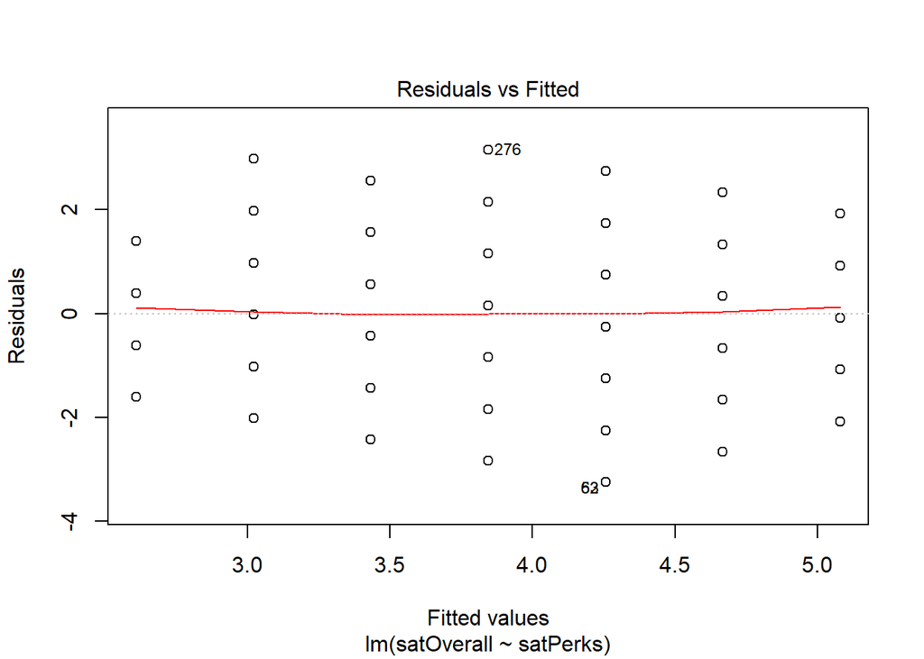

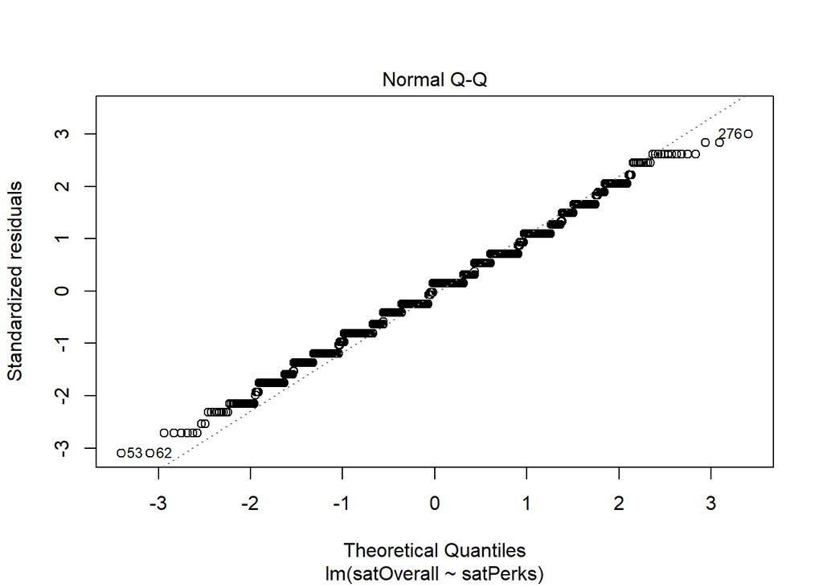

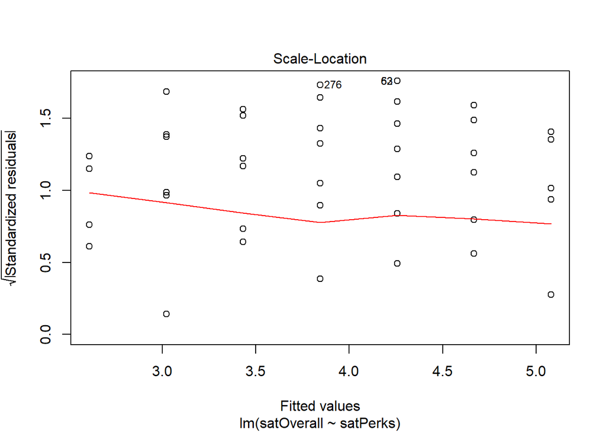

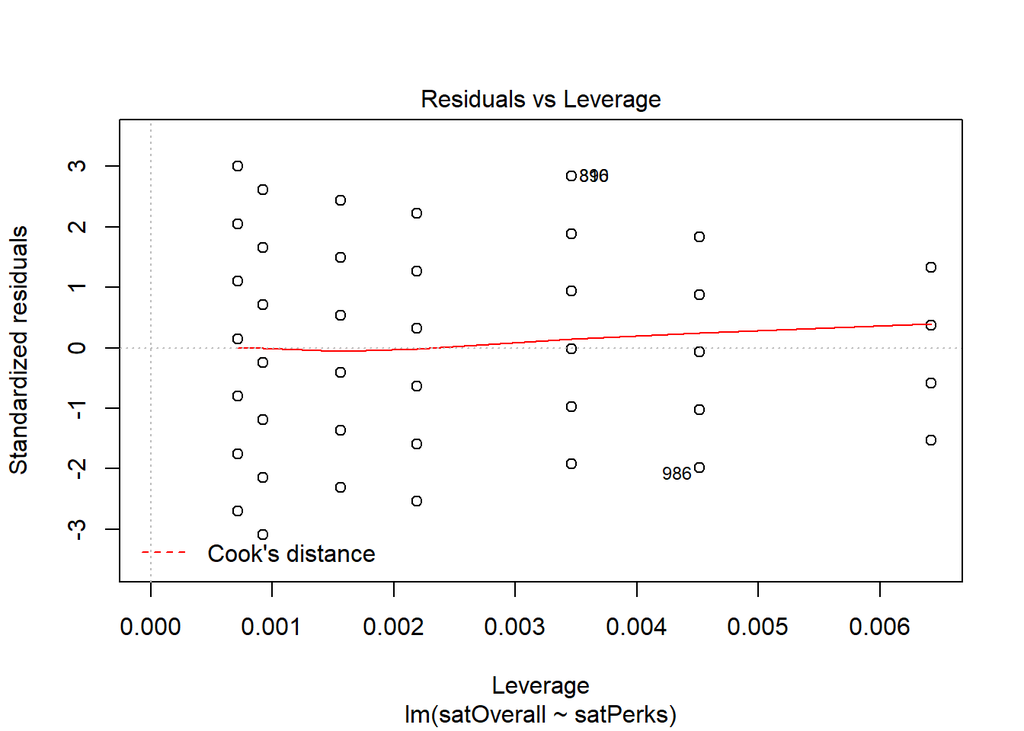

```r
plot(q1)
```

```r
print('As per the observations we can see that , the mean of residuals is very close to zero.
1)The residuals are normally distributed.

2) The residuals do not have increasing or decreasing spend they tend to be fairly scattered throughout


3)The graph is unable to see the cooks line .896 and 986 seem a bit off so we must remove them from our analysis ')
```

[output not shown]

### Exercise 3 (10 Points)

- Expand the model created in Exercise 1 by adding the elite membership level (eliteStatus) as another predictor
- Based on the model results, interpret the coefficients of eliteStatus

```r
q3 <- lm(satOverall~satPerks+eliteStatus, data = hotel.df)
summary(q3)
```

```
##
## Call:
## lm(formula = satOverall ~ satPerks + eliteStatus, data = hotel.df)
##
## Residuals:
##     Min      1Q  Median      3Q     Max
## -3.1697 -0.6630 -0.0144  0.6719  3.0233
##
## Coefficients:
##                     Estimate Std. Error t value Pr(>|t|)
## (Intercept)          2.75950    0.14659  18.825  < 2e-16 ***
## satPerks             0.31372    0.02766  11.340  < 2e-16 ***
## eliteStatusNoStatus -0.35140    0.08104  -4.336 1.55e-05 ***
## eliteStatusPlatinum  0.40493    0.10479   3.864 0.000116 ***
## eliteStatusSilver   -0.15841    0.07638  -2.074 0.038243 *
## ---
## Signif. codes:  0 '***' 0.001 '**' 0.01 '*' 0.05 '.' 0.1 ' ' 1
##
## Residual standard error: 1.034 on 1495 degrees of freedom
## Multiple R-squared:  0.1908, Adjusted R-squared:  0.1886
## F-statistic: 88.12 on 4 and 1495 DF,  p-value: < 2.2e-16
```

```r
str(q3)
```

[output not shown]

[output cut: 8 more lines]

[output not shown]

### Exercise 4 (10 Points)

- Use the model created in Exercise 3 to estimate the average overall satisfaction if all the respondents have “Gold” status (eliteStatus) while everything else is kept as is

```r
mean(predict.lm(q3,newdata = hotel.df[hotel.df$eliteStatus == 'Gold',]))
```

```
## [1] 4.279605
```

```r
que4.df <- hotel.df
que4.df$eliteStatus <- 'Gold'
mean(predict.lm(q3,newdata=que4.df))
```

```
## [1] 4.108712
```

### Exercise 5 (10 Points)

- The model created in Exercise 1 is nested within the model of Exercise 3. Use anova() to determine whether the overall fit of the model in Exercise 1 is statistically significantly different from that of the model in Exercise 3

```r
t<-anova(q1,q3)
t
```

```
## Analysis of Variance Table
##
## Model 1: satOverall ~ satPerks
## Model 2: satOverall ~ satPerks + eliteStatus
##   Res.Df    RSS Df Sum of Sq     F    Pr(>F)
## 1   1498 1655.6
## 2   1495 1599.4  3    56.228 17.52 3.516e-11 ***
## ---
## Signif. codes:  0 '***' 0.001 '**' 0.01 '*' 0.05 '.' 0.1 ' ' 1
```